# Customer Classification: Credit Risk Analysis

Jordy Alfaro

2025-04-19

# Introduction

## Credit Risk Analysis Context

In the financial sector, predicting whether a borrower will default on a loan is a critical task with significant business implications. This analysis focuses on developing a classification model to predict loan defaults based on customer characteristics and loan attributes.

Credit risk assessment is essential for:

1. **Risk Management**: Minimizing potential losses from loan defaults
2. **Customer Selection**: Identifying creditworthy applicants
3. **Portfolio Optimization**: Maintaining a healthy balance of risk and return
4. **Regulatory Compliance**: Meeting financial industry standards for risk assessment

This analysis will employ multiple machine learning approaches, including Random Forest, Neural Networks, and Naive Bayes, to develop a robust classification system. The resulting model will enable more informed lending decisions, potentially reducing default rates while maintaining loan accessibility for qualified customers.

## Dataset Description

The dataset contains information on loan applicants and their loan status, with the following key variables:

**Customer Demographics**: - `person_age`: Age of the applicant - `person_income`: Annual income - `person_home_ownership`: Housing status (RENT, MORTGAGE, OWN, OTHER) - `person_emp_length`: Employment length in years - `cb_person_default_on_file`: Whether the person has defaulted in the past (Y/N) - `cb_person_cred_hist_length`: Length of credit history in years

**Loan Characteristics**: - `loan_intent`: Purpose of the loan (EDUCATION, MEDICAL, VENTURE, PERSONAL, HOMEIMPROVEMENT, DEBTCONSOLIDATION) - `loan_grade`: Loan grade assigned by the lender (A to G) - `loan_amnt`: Loan amount - `loan_int_rate`: Interest rate - `loan_percent_income`: Ratio of loan amount to income

**Target Variable**: - `loan_status`: Whether the loan defaulted (1) or not (0)

## Business Objectives

Through this analysis, we aim to:

1. Identify key factors that influence loan default risk
2. Develop a predictive model that accurately classifies high-risk applicants
3. Compare different modeling approaches to determine the most effective for credit risk prediction
4. Create an actionable framework for loan approval decisions
5. Quantify the potential business impact of implementing the model

The insights gained will support data-driven lending strategies that balance risk mitigation with business growth objectives.

# Data Loading and Sampling

To ensure computational efficiency while maintaining statistical validity, we work with a randomly selected sample of 10,000 observations from the original credit risk dataset.

```r
# Set seed for reproducibility
set.seed(123)

# Load the original data
credit_data <- read.csv("credit_risk_dataset.csv")

# Take a sample of 10,000 observations
sample_indices <- sample(1:nrow(credit_data), 10000)
credit_data <- credit_data[sample_indices, ]

# Verify dimensions of the sample
cat("Sample dimensions:", dim(credit_data), "\n")
```

```
## Sample dimensions: 10000 12
```

# Data Exploration and Preparation

## Initial Data Inspection

```r
# Display the structure of the dataset
str(credit_data)
```

```
## 'data.frame':    10000 obs. of  12 variables:
##  $ person_age                : int  30 29 28 29 28 24 25 27 23 41 ...
##  $ person_income             : int  27996 18000 114000 34999 80000 25000 97440 54000 36000 121200 ...
##  $ person_home_ownership     : chr  "RENT" "RENT" "MORTGAGE" "RENT" ...
##  $ person_emp_length         : num  9 3 12 2 13 6 9 2 2 1 ...
##  $ loan_intent               : chr  "MEDICAL" "MEDICAL" "VENTURE" "MEDICAL" ...
##  $ loan_grade                : chr  "C" "B" "E" "B" ...
##  $ loan_amnt                 : int  1500 1700 8000 12000 21000 3200 15000 12100 5000 10000 ...
##  $ loan_int_rate             : num  NA 11.1 18.6 11.6 11.4 ...
##  $ loan_status               : int  0 0 0 1 0 1 0 0 0 0 ...
##  $ loan_percent_income       : num  0.05 0.09 0.07 0.34 0.26 0.13 0.15 0.22 0.14 0.08 ...
##  $ cb_person_default_on_file : chr  "Y" "N" "N" "N" ...
##  $ cb_person_cred_hist_length: int  8 10 10 10 10 4 4 6 3 13 ...
```

```r
# View the first few rows
head(credit_data)
```

|  | person_age | person_income | person_home_ownership | person_emp_length | loan_intent | loan_grade | loan_amnt | loan_int_rate | loan_status | loan_percent_income | cb_person_default_on_file | cb_person_cred_hist_length |
| --- | --- | --- | --- | --- | --- | --- | --- | --- | --- | --- | --- | --- |
| 18847 | 30 | 27996 | RENT | 9 | MEDICAL | C | 1500 | NA | 0 | 0.05 | Y | 8 |
| 18895 | 29 | 18000 | RENT | 3 | MEDICAL | B | 1700 | 11.12 | 0 | 0.09 | N | 10 |
| 26803 | 28 | 114000 | MORTGAGE | 12 | VENTURE | E | 8000 | 18.64 | 0 | 0.07 | N | 10 |
| 25102 | 29 | 34999 | RENT | 2 | MEDICAL | B | 12000 | 11.58 | 1 | 0.34 | N | 10 |
| 28867 | 28 | 80000 | MORTGAGE | 13 | EDUCATION | B | 21000 | 11.36 | 0 | 0.26 | N | 10 |
| 2986 | 24 | 25000 | RENT | 6 | DEBTCONSOLIDATION | C | 3200 | 13.11 | 1 | 0.13 | N | 4 |

```r
# Check dimensions
cat("Number of observations:", nrow(credit_data), "\n")
```

```
## Number of observations: 10000
```

```r
cat("Number of variables:", ncol(credit_data), "\n")
```

```
## Number of variables: 12
```

```r
# Check for missing values
missing_values <- colSums(is.na(credit_data))
cat("Missing values per column:\n")
```

```
## Missing values per column:
```

```r
print(missing_values)
```

```
##                 person_age              person_income
##                          0                          0
##      person_home_ownership          person_emp_length
##                          0                        283
##                loan_intent                 loan_grade
##                          0                          0
##                  loan_amnt              loan_int_rate
##                          0                        939
##                loan_status        loan_percent_income
##                          0                          0
##  cb_person_default_on_file cb_person_cred_hist_length
##                          0                          0
```

## Data Cleaning and Preparation

```r
# Make a copy of the original data
clean_data <- credit_data

# Check for missing values before proceeding
missing_values <- colSums(is.na(clean_data))
cat("Missing values per column before cleaning:\n")
```

```
## Missing values per column before cleaning:
```

```r
print(missing_values)
```

```
##                 person_age              person_income
##                          0                          0
##      person_home_ownership          person_emp_length
##                          0                        283
##                loan_intent                 loan_grade
##                          0                          0
##                  loan_amnt              loan_int_rate
##                          0                        939
##                loan_status        loan_percent_income
##                          0                          0
##  cb_person_default_on_file cb_person_cred_hist_length
##                          0                          0
```

```r
# Handle missing values where necessary
# For employment length, replace NA with median
if(sum(is.na(clean_data$person_emp_length)) > 0) {
  clean_data$person_emp_length[is.na(clean_data$person_emp_length)] <-
    median(clean_data$person_emp_length, na.rm = TRUE)
}

# For interest rate, replace NA with median per loan grade
if(sum(is.na(clean_data$loan_int_rate)) > 0) {
  # Group by loan grade and impute with median
  medians_by_grade <- clean_data %>%
    group_by(loan_grade) %>%
    summarise(median_rate = median(loan_int_rate, na.rm = TRUE))

  # Apply imputation
  for(grade in unique(clean_data$loan_grade)) {
    median_for_grade <- medians_by_grade$median_rate[medians_by_grade$loan_grade == grade]
    idx <- is.na(clean_data$loan_int_rate) & clean_data$loan_grade == grade
    clean_data$loan_int_rate[idx] <- median_for_grade
  }
}

# Check remaining missing values after imputation
missing_values_after <- colSums(is.na(clean_data))
cat("Missing values per column after imputation:\n")
```

```
## Missing values per column after imputation:
```

```r
print(missing_values_after)
```

```
##                 person_age              person_income
##                          0                          0
##      person_home_ownership          person_emp_length
##                          0                          0
##                loan_intent                 loan_grade
##                          0                          0
##                  loan_amnt              loan_int_rate
##                          0                          0
##                loan_status        loan_percent_income
##                          0                          0
##  cb_person_default_on_file cb_person_cred_hist_length
##                          0                          0
```

```r
# Convert categorical variables to factors
clean_data$person_home_ownership <- as.factor(clean_data$person_home_ownership)
clean_data$loan_intent <- as.factor(clean_data$loan_intent)
clean_data$loan_grade <- as.factor(clean_data$loan_grade)
clean_data$cb_person_default_on_file <- as.factor(clean_data$cb_person_default_on_file)
clean_data$loan_status <- as.factor(clean_data$loan_status)

# Rename factor levels to ensure they are valid R variable names
levels(clean_data$loan_status) <- c("no_default", "default")

# Check the new factor levels
print(levels(clean_data$loan_status))
```

```
## [1] "no_default" "default"
```

```r
# Check for and handle outliers in numerical variables
numerical_vars <- c("person_age", "person_income", "person_emp_length",
                   "loan_amnt", "loan_int_rate", "loan_percent_income",
                   "cb_person_cred_hist_length")

# Create a function to identify outliers using IQR method
identify_outliers <- function(x) {
  q1 <- quantile(x, 0.25, na.rm = TRUE)
  q3 <- quantile(x, 0.75, na.rm = TRUE)
  iqr <- q3 - q1
  lower_bound <- q1 - 1.5 * iqr
  upper_bound <- q3 + 1.5 * iqr
  outliers <- sum(x < lower_bound | x > upper_bound, na.rm = TRUE)
  return(c(lower_bound, upper_bound, outliers))
}

# Apply the function to numerical variables
outlier_summary <- sapply(clean_data[numerical_vars], identify_outliers)
rownames(outlier_summary) <- c("Lower Bound", "Upper Bound", "Outlier Count")
kable(outlier_summary, caption = "Summary of Outliers by Numerical Variable") %>%
  kable_styling(bootstrap_options = c("striped", "hover"))
```

Summary of Outliers by Numerical Variable

|  | person_age | person_income | person_emp_length | loan_amnt | loan_int_rate | loan_percent_income | cb_person_cred_hist_length |
| --- | --- | --- | --- | --- | --- | --- | --- |
| Lower Bound | 12.5 | -21750 | -5.5 | -5500 | -0.47 | -0.12 | -4.5 |
| Upper Bound | 40.5 | 138650 | 14.5 | 22500 | 21.85 | 0.44 | 15.5 |
| Outlier Count | 457.0 | 484 | 275.0 | 504 | 2.00 | 191.00 | 351.0 |

```r
# Cap extreme values for person_income and loan_amnt (keeping the data but reducing extreme influence)
clean_data$person_income <- pmin(clean_data$person_income, outlier_summary["Upper Bound", "person_income"])
clean_data$loan_amnt <- pmin(clean_data$loan_amnt, outlier_summary["Upper Bound", "loan_amnt"])

# Check for any logical inconsistencies or errors
# Example: Check for unrealistic age values
clean_data <- clean_data %>% filter(person_age >= 18 & person_age <= 100)

# Create age groups for easier interpretation
clean_data$age_group <- cut(clean_data$person_age,
                         breaks = c(18, 25, 35, 45, 55, 65, 100),
                         labels = c("18-25", "26-35", "36-45", "46-55", "56-65", "65+"),
                         right = FALSE)

# Create income groups
clean_data$income_group <- cut(clean_data$person_income,
                            breaks = c(0, 25000, 50000, 75000, 100000, 1000000),
                            labels = c("<25K", "25K-50K", "50K-75K", "75K-100K", "100K+"),
                            right = FALSE)

# Create loan amount groups
clean_data$loan_amount_group <- cut(clean_data$loan_amnt,
                                 breaks = c(0, 5000, 10000, 15000, 20000, 30000, 50000),
                                 labels = c("<5K", "5K-10K", "10K-15K", "15K-20K", "20K-30K", "30K+"),
                                 right = FALSE)

# Summarize the cleaned dataset
cat("Observations after cleaning:", nrow(clean_data), "\n")
```

```
## Observations after cleaning: 9999
```

```r
cat("Original observations:", nrow(credit_data), "\n")
```

```
## Original observations: 10000
```

```r
cat("Removed observations:", nrow(credit_data) - nrow(clean_data), "\n")
```

```
## Removed observations: 1
```

## Data Cleaning and Preprocessing Summary

Our initial inspection revealed missing values in two key variables:

- Employment length: 283 missing values (2.83%)
- Interest rate: 939 missing values (9.39%)

We implemented an imputation strategy: - For employment length, missing values were replaced with the median value - For interest rate, we imputed values based on the median rate for each loan grade

The outlier analysis using the IQR method identified: - Annual income: 484 outliers (4.84%), with an upper bound of $138,650 - Loan amount: 504 outliers (5.04%), with an upper bound of $22,500

To mitigate the impact of extreme values while preserving valid observations, we applied capping to income and loan amount variables.

## Exploratory Data Analysis

### Target Variable Distribution

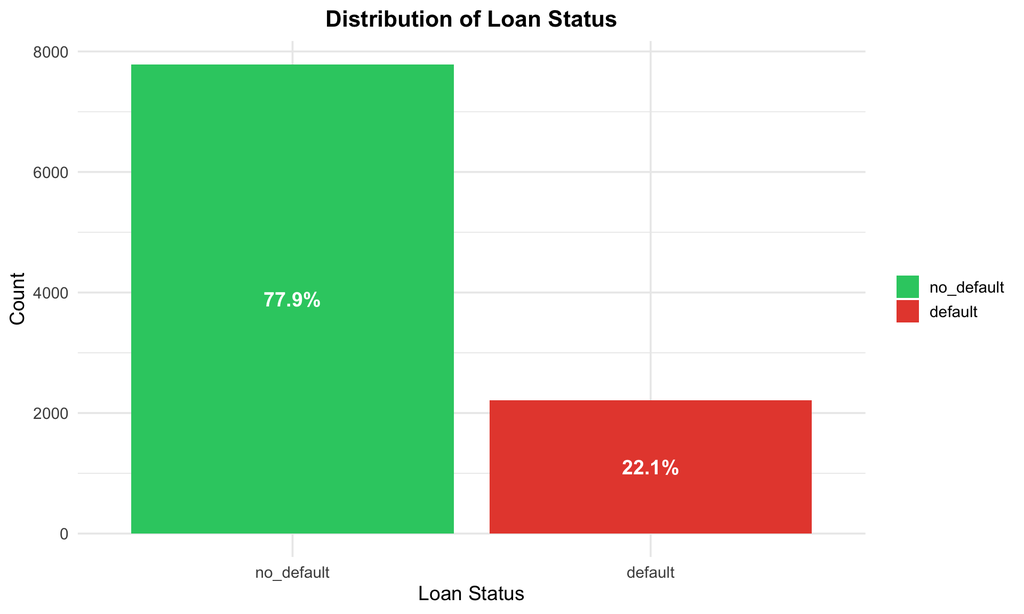

```r
# Analyze the distribution of the target variable
target_dist <- clean_data %>%
  count(loan_status) %>%
  mutate(percentage = n / sum(n) * 100)

ggplot(target_dist, aes(x = loan_status, y = n, fill = loan_status)) +
  geom_bar(stat = "identity") +
  geom_text(aes(label = paste0(round(percentage, 1), "%")),
            position = position_stack(vjust = 0.5),
            color = "white", size = 5, fontface = "bold") +
  scale_fill_manual(values = c("no_default" = "#2ecc71", "default" = "#e74c3c")) +
  labs(title = "Distribution of Loan Status",
       x = "Loan Status",
       y = "Count") +
  theme_minimal(base_size = 14) +
  theme(legend.title = element_blank(),
        plot.title = element_text(hjust = 0.5, face = "bold", size = 16))
```

The dataset exhibits a class imbalance, with 77.9% of loans performing normally (“no_default”) and 22.1% resulting in default. This imbalance reflects real-world credit risk distributions and creates challenges for model development.

### Numerical Variables

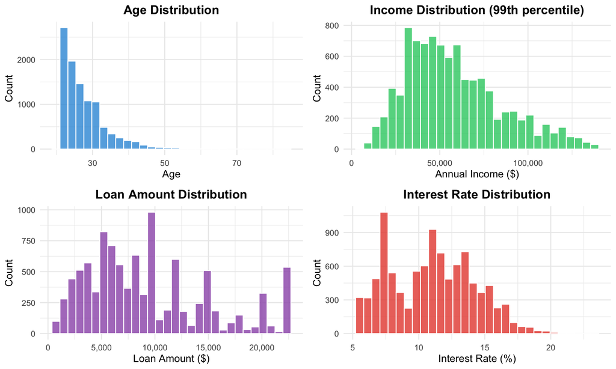

```r
# Visualize key numerical variables
p1 <- ggplot(clean_data, aes(x = person_age)) +
  geom_histogram(bins = 30, fill = "#3498db", color = "white", alpha = 0.8) +
  labs(title = "Age Distribution", x = "Age", y = "Count") +
  theme_minimal(base_size = 12) +
  theme(plot.title = element_text(hjust = 0.5, face = "bold"))

p2 <- ggplot(clean_data %>% filter(person_income < quantile(person_income, 0.99)),
             aes(x = person_income)) +
  geom_histogram(bins = 30, fill = "#2ecc71", color = "white", alpha = 0.8) +
  labs(title = "Income Distribution (99th percentile)", x = "Annual Income ($)", y = "Count") +
  scale_x_continuous(labels = comma) +
  theme_minimal(base_size = 12) +
  theme(plot.title = element_text(hjust = 0.5, face = "bold"))

p3 <- ggplot(clean_data, aes(x = loan_amnt)) +
  geom_histogram(bins = 30, fill = "#9b59b6", color = "white", alpha = 0.8) +
  labs(title = "Loan Amount Distribution", x = "Loan Amount ($)", y = "Count") +
  scale_x_continuous(labels = comma) +
  theme_minimal(base_size = 12) +
  theme(plot.title = element_text(hjust = 0.5, face = "bold"))

p4 <- ggplot(clean_data, aes(x = loan_int_rate)) +
  geom_histogram(bins = 30, fill = "#e74c3c", color = "white", alpha = 0.8) +
  labs(title = "Interest Rate Distribution", x = "Interest Rate (%)", y = "Count") +
  theme_minimal(base_size = 12) +
  theme(plot.title = element_text(hjust = 0.5, face = "bold"))

# Arrange plots in a grid
grid.arrange(p1, p2, p3, p4, ncol = 2)
```

### Categorical Variables

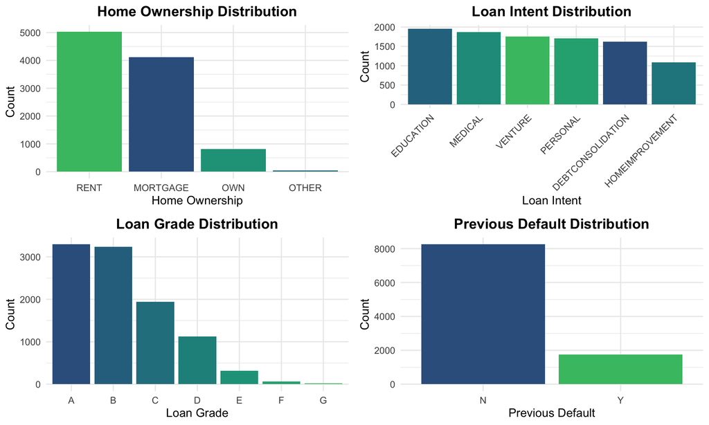

```r
# Visualize categorical variables
p5 <- ggplot(clean_data, aes(x = fct_infreq(person_home_ownership), fill = person_home_ownership)) +
  geom_bar() +
  scale_fill_viridis_d(option = "D", begin = 0.3, end = 0.7) +
  labs(title = "Home Ownership Distribution", x = "Home Ownership", y = "Count") +
  theme_minimal(base_size = 12) +
  theme(plot.title = element_text(hjust = 0.5, face = "bold"),
        legend.position = "none")

p6 <- ggplot(clean_data, aes(x = fct_infreq(loan_intent), fill = loan_intent)) +
  geom_bar() +
  scale_fill_viridis_d(option = "D", begin = 0.3, end = 0.7) +
  labs(title = "Loan Intent Distribution", x = "Loan Intent", y = "Count") +
  theme_minimal(base_size = 12) +
  theme(plot.title = element_text(hjust = 0.5, face = "bold"),
        legend.position = "none",
        axis.text.x = element_text(angle = 45, hjust = 1))

p7 <- ggplot(clean_data, aes(x = fct_infreq(loan_grade), fill = loan_grade)) +
  geom_bar() +
  scale_fill_viridis_d(option = "D", begin = 0.3, end = 0.7) +
  labs(title = "Loan Grade Distribution", x = "Loan Grade", y = "Count") +
  theme_minimal(base_size = 12) +
  theme(plot.title = element_text(hjust = 0.5, face = "bold"),
        legend.position = "none")

p8 <- ggplot(clean_data, aes(x = fct_infreq(cb_person_default_on_file), fill = cb_person_default_on_file)) +
  geom_bar() +
  scale_fill_viridis_d(option = "D", begin = 0.3, end = 0.7) +
  labs(title = "Previous Default Distribution", x = "Previous Default", y = "Count") +
  theme_minimal(base_size = 12) +
  theme(plot.title = element_text(hjust = 0.5, face = "bold"),
        legend.position = "none")

# Arrange categorical plots
grid.arrange(p5, p6, p7, p8, ncol = 2)
```

Key observations from categorical variables:

- **Home Ownership**: Most applicants are renters (approximately 50%), followed by mortgage holders (about 41%)
- **Loan Intent**: Relatively even distribution across categories, with slightly higher frequencies for education and medical purposes
- **Loan Grade**: Heavily weighted toward higher quality ratings (A and B), with progressive decrease through grades C through G
- **Previous Default**: Approximately 85% of applicants had no prior defaults, while about 15% had defaulted previously

### Bivariate Analysis: Relationship with Target

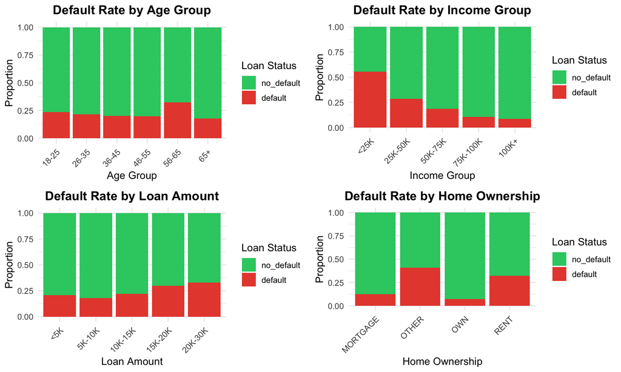

```r
# Function to create comparison plots
create_barplot <- function(data, var_name, title, x_label = NULL) {
  if(is.null(x_label)) x_label <- var_name

  ggplot(data, aes_string(x = var_name, fill = "loan_status")) +
    geom_bar(position = "fill") +
    scale_fill_manual(values = c("no_default" = "#2ecc71", "default" = "#e74c3c")) +
    labs(title = title, x = x_label, y = "Proportion", fill = "Loan Status") +
    theme_minimal(base_size = 12) +
    theme(
      axis.text.x = element_text(angle = 45, hjust = 1),
      plot.title = element_text(hjust = 0.5, face = "bold"),
      legend.position = "right"
    )
}

# Create key comparison visualizations
age_plot <- create_barplot(clean_data, "age_group", "Default Rate by Age Group", "Age Group")
income_plot <- create_barplot(clean_data, "income_group", "Default Rate by Income Group", "Income Group")
loan_amt_plot <- create_barplot(clean_data, "loan_amount_group", "Default Rate by Loan Amount", "Loan Amount")
ownership_plot <- create_barplot(clean_data, "person_home_ownership", "Default Rate by Home Ownership", "Home Ownership")

# Arrange plots in grid
grid.arrange(age_plot, income_plot, loan_amt_plot, ownership_plot, ncol = 2)
```

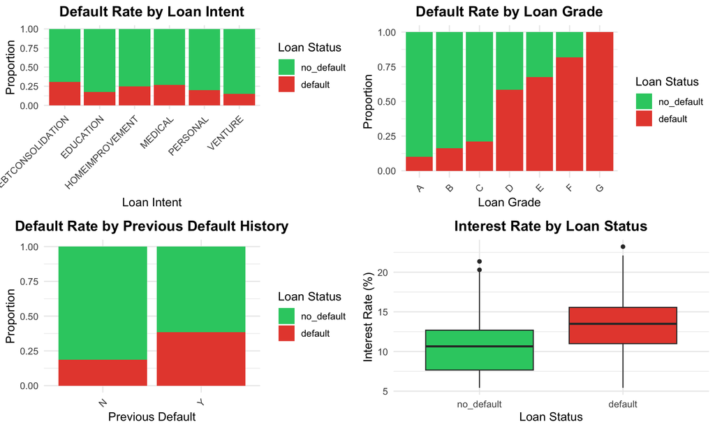

```r
# Additional comparison plots
intent_plot <- create_barplot(clean_data, "loan_intent", "Default Rate by Loan Intent", "Loan Intent")
grade_plot <- create_barplot(clean_data, "loan_grade", "Default Rate by Loan Grade", "Loan Grade")
prev_default_plot <- create_barplot(clean_data, "cb_person_default_on_file", "Default Rate by Previous Default History", "Previous Default")

# Create a boxplot for interest rate by default status
int_rate_plot <- ggplot(clean_data, aes(x = loan_status, y = loan_int_rate, fill = loan_status)) +
  geom_boxplot() +
  scale_fill_manual(values = c("no_default" = "#2ecc71", "default" = "#e74c3c")) +
  labs(title = "Interest Rate by Loan Status",
       x = "Loan Status",
       y = "Interest Rate (%)") +
  theme_minimal(base_size = 12) +
  theme(
    plot.title = element_text(hjust = 0.5, face = "bold"),
    legend.position = "none"
  )

# Arrange second set of plots
grid.arrange(intent_plot, grade_plot, prev_default_plot, int_rate_plot, ncol = 2)
```

### Correlation Analysis

```r
# Select numerical variables for correlation analysis
numerical_vars <- c("person_age", "person_income", "person_emp_length",
                   "loan_amnt", "loan_int_rate", "loan_percent_income",
                   "cb_person_cred_hist_length")

# Add the target variable as numeric for correlation calculation
# First check if we can convert the factor to numeric correctly
if(is.factor(clean_data$loan_status)) {
  # Determine which level corresponds to "default"
  default_level <- which(levels(clean_data$loan_status) == "default")
  if(length(default_level) == 0) {
    # If "default" is not found, assume the second level is positive class
    default_level <- 2
  }

  # Convert factor to numeric (1 for default, 0 for no_default)
  loan_status_num <- as.integer(as.integer(clean_data$loan_status) == default_level)
} else {
  # Fallback if loan_status is not a factor
  loan_status_num <- as.integer(clean_data$loan_status)
}

# Create correlation data and handle missing values
correlation_data <- clean_data %>%
  select(all_of(numerical_vars))

# Add loan_status_num to correlation_data
correlation_data$loan_status_num <- loan_status_num

# Check for missing values in correlation data
na_counts <- colSums(is.na(correlation_data))
cat("Missing values in correlation data:\n")
```

```
## Missing values in correlation data:
```

```r
print(na_counts)
```

```
##                 person_age              person_income
##                          0                          0
##          person_emp_length                  loan_amnt
##                          0                          0
##              loan_int_rate        loan_percent_income
##                          0                          0
## cb_person_cred_hist_length            loan_status_num
##                          0                          0
```

```r
# Handle missing values by imputation for correlation analysis only
for(col in colnames(correlation_data)) {
  if(sum(is.na(correlation_data[[col]])) > 0) {
    # Impute NA with median for numerical columns
    correlation_data[[col]][is.na(correlation_data[[col]])] <-
      median(correlation_data[[col]], na.rm = TRUE)
  }
}

# Verify imputation worked
na_counts_after <- colSums(is.na(correlation_data))
cat("Missing values after imputation:\n")
```

```
## Missing values after imputation:
```

```r
print(na_counts_after)
```

```
##                 person_age              person_income
##                          0                          0
##          person_emp_length                  loan_amnt
##                          0                          0
##              loan_int_rate        loan_percent_income
##                          0                          0
## cb_person_cred_hist_length            loan_status_num
##                          0                          0
```

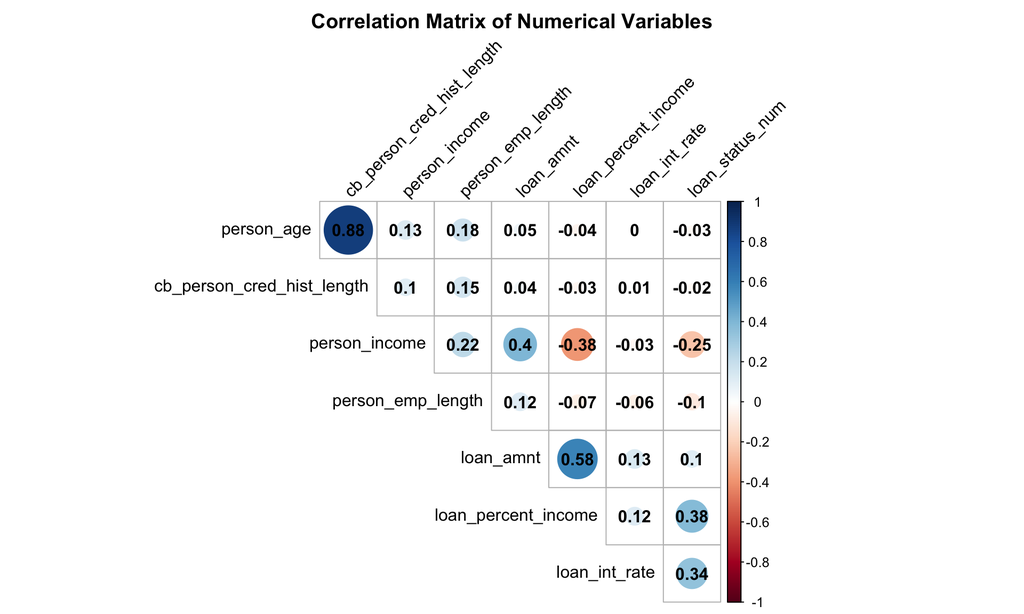

```r
# Calculate pairwise correlation matrix
correlation <- cor(correlation_data)

# Plot correlation matrix
corrplot(correlation,
         method = "circle",
         type = "upper",
         order = "hclust",
         addCoef.col = "black",
         tl.col = "black",
         tl.srt = 45,
         diag = FALSE,
         title = "Correlation Matrix of Numerical Variables",
         mar = c(0,0,2,0))
```

```r
# Feature importance analysis - create simple models to assess variable importance
# First, check for any NA values in the data
na_count <- colSums(is.na(clean_data))
print(na_count)
```

```
##                 person_age              person_income
##                          0                          0
##      person_home_ownership          person_emp_length
##                          0                          0
##                loan_intent                 loan_grade
##                          0                          0
##                  loan_amnt              loan_int_rate
##                          0                          0
##                loan_status        loan_percent_income
##                          0                          0
##  cb_person_default_on_file cb_person_cred_hist_length
##                          0                          0
##                  age_group               income_group
##                          0                          0
##          loan_amount_group
##                          0
```

```r
# Remove rows with NA values or impute as needed
clean_data_no_na <- clean_data %>% drop_na()
cat("Original data rows:", nrow(clean_data), "\n")
```

```
## Original data rows: 9999
```

```r
cat("Rows after removing NA values:", nrow(clean_data_no_na), "\n")
```

```
## Rows after removing NA values: 9999
```

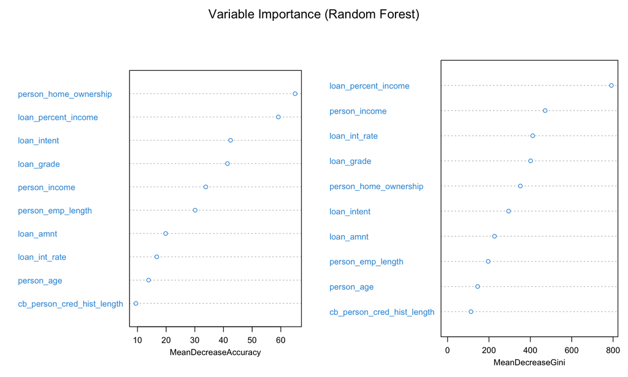

```r
# Now build the model using the data without NA values
model_formula <- as.formula("loan_status ~ person_age + person_income + person_home_ownership +
                            person_emp_length + loan_intent + loan_grade + loan_amnt +
                            loan_int_rate + loan_percent_income + cb_person_default_on_file +
                            cb_person_cred_hist_length")

# Random Forest for variable importance
set.seed(123)
rf_model <- randomForest(model_formula, data = clean_data_no_na, importance = TRUE, ntree = 100)

# Plot variable importance
varImpPlot(rf_model,
           sort = TRUE,
           main = "Variable Importance (Random Forest)",
           n.var = 10,
           cex = 0.8,
           color = "#3498db")
```

Key insights from correlation analysis:

- Strong positive correlation (0.88) between borrower age and credit history length
- Moderate positive correlations between income and employment length (0.22) and loan amount (0.40)
- Negative correlation (-0.38) between income and loan percent income
- Moderate correlations between default status and income (-0.25), loan percent income (0.38), and interest rate (0.34)

Feature importance analysis shows:

- Mean Decrease Accuracy: Home ownership status, loan percent income, and loan intent emerge as top predictors
- Mean Decrease Gini: Loan percent income stands out as the single most important predictor, followed by income, interest rate, and loan grade
- Financial burden metrics and loan terms are more predictive than borrower demographics

# Feature Engineering and Preprocessing

```r
# Create a dataset for modeling
model_data <- clean_data

# Make sure loan_status has proper factor levels
if(is.factor(model_data$loan_status)) {
  current_levels <- levels(model_data$loan_status)
  if(any(current_levels %in% c("0", "1"))) {
    levels(model_data$loan_status) <- c("no_default", "default")
    cat("Loan status levels renamed to:", levels(model_data$loan_status), "\n")
  }
}

# Create interaction features
model_data$income_to_loan_ratio <- model_data$person_income / model_data$loan_amnt
model_data$income_per_credit_year <- model_data$person_income / pmax(model_data$cb_person_cred_hist_length, 1)
model_data$debt_to_income <- model_data$loan_percent_income * 100

# Map loan_grade to numeric values
grade_map <- c("A" = 1, "B" = 2, "C" = 3, "D" = 4, "E" = 5, "F" = 6, "G" = 7)
model_data$grade_numeric <- grade_map[as.character(model_data$loan_grade)]
model_data$risk_factor <- model_data$grade_numeric * model_data$loan_int_rate

# One-hot encode categorical variables
model_matrix <- model.matrix(~ person_home_ownership + loan_intent + loan_grade + cb_person_default_on_file - 1, data = model_data)

# Combine with numerical variables
model_data_encoded <- cbind(
  model_data %>% select(person_age, person_income, person_emp_length, loan_amnt,
                       loan_int_rate, loan_percent_income, cb_person_cred_hist_length,
                       income_to_loan_ratio, income_per_credit_year, debt_to_income, risk_factor,
                       loan_status),
  as.data.frame(model_matrix)
)

# Split into training and testing sets
set.seed(123)
train_index <- createDataPartition(model_data_encoded$loan_status, p = 0.7, list = FALSE)
train_data <- model_data_encoded[train_index, ]
test_data <- model_data_encoded[-train_index, ]

# Verify dimensions
cat("Training set dimensions:", dim(train_data), "\n")
```

```
## Training set dimensions: 7001 28
```

```r
cat("Testing set dimensions:", dim(test_data), "\n")
```

```
## Testing set dimensions: 2998 28
```

```r
# Check the class distribution in training and testing sets
train_class_dist <- table(train_data$loan_status)
test_class_dist <- table(test_data$loan_status)

cat("Class distribution in training set:\n")
```

```
## Class distribution in training set:
```

```r
print(prop.table(train_class_dist))
```

```
##
## no_default    default
##  0.7786031  0.2213969
```

```r
cat("Class distribution in testing set:\n")
```

```
## Class distribution in testing set:
```

```r
print(prop.table(test_class_dist))
```

```
##
## no_default    default
##  0.7788526  0.2211474
```

```r
# Prepare predictors and target
x_train <- train_data %>% select(-loan_status)
y_train <- train_data$loan_status

x_test <- test_data %>% select(-loan_status)
y_test <- test_data$loan_status

# Scale numerical features for models like Neural Network
preprocess_params <- preProcess(x_train, method = c("center", "scale"))
x_train_scaled <- predict(preprocess_params, x_train)
x_test_scaled <- predict(preprocess_params, x_test)

# Verify no NAs in the data
sum(is.na(x_train))
```

```
## [1] 0
```

```r
sum(is.na(x_test))
```

```
## [1] 0
```

We implemented a comprehensive feature engineering approach:

**Financial Ratios:** - Income-to-loan ratio: Measuring a borrower’s ability to manage the loan relative to their resources - Income per credit year: Normalizing income against credit history length - Debt-to-income conversion: Converting loan percent income to a more interpretable percentage metric

**Risk Assessment Variables:** - Grade numeric encoding: Converting categorical loan grades (A-G) to a numerical scale (1-7) - Risk factor: Creating an interaction term between grade numeric and interest rate

These engineered features enhance the model’s ability to capture nuanced relationships beyond what individual variables can detect. For categorical variables, we implemented one-hot encoding for home ownership status, loan intent, loan grade, and previous default history.

The preprocessed dataset was divided into training (70%) and testing (30%) sets while maintaining consistent class distribution across both partitions: - Training set: 7,001 observations with 22.1% default rate - Testing set: 2,998 observations with 22.1% default rate

For models sensitive to feature scales (particularly Neural Networks), we applied standardization to numerical features.

# Model Training and Evaluation

## Random Forest Model

```r
# Set control parameters with cross-validation
set.seed(123)
ctrl <- trainControl(
  method = "cv",
  number = 5,
  classProbs = TRUE,
  summaryFunction = twoClassSummary,
  savePredictions = TRUE
)

# Train Random Forest model with lighter parameters for better performance
rf_model <- train(
  x = x_train,
  y = y_train,
  method = "rf",
  trControl = ctrl,
  metric = "ROC",
  tuneLength = 3,
  importance = TRUE,
  ntree = 100  # Reduced for faster processing
)

# Evaluate on test set
rf_pred <- predict(rf_model, x_test)
rf_prob <- predict(rf_model, x_test, type = "prob")

# Create confusion matrix
rf_cm <- confusionMatrix(rf_pred, y_test, positive = "default")

# Print results
print(rf_model)
```

```
## Random Forest
##
## 7001 samples
##   27 predictor
##    2 classes: 'no_default', 'default'
##
## No pre-processing
## Resampling: Cross-Validated (5 fold)
## Summary of sample sizes: 5601, 5601, 5600, 5601, 5601
## Resampling results across tuning parameters:
##
##   mtry  ROC        Sens       Spec
##    2    0.9066746  0.9776187  0.6561290
##   14    0.9159421  0.9855073  0.7103226
##   27    0.9113685  0.9851403  0.7058065
##
## ROC was used to select the optimal model using the largest value.
## The final value used for the model was mtry = 14.
```

```r
print(rf_cm)
```

```
## Confusion Matrix and Statistics
##
##             Reference
## Prediction   no_default default
##   no_default       2299     166
##   default            36     497
##
##                Accuracy : 0.9326
##                  95% CI : (0.9231, 0.9413)
##     No Information Rate : 0.7789
##     P-Value [Acc > NIR] : < 2.2e-16
##
##                   Kappa : 0.7896
##
##  Mcnemar's Test P-Value : < 2.2e-16
##
##             Sensitivity : 0.7496
##             Specificity : 0.9846
##          Pos Pred Value : 0.9325
##          Neg Pred Value : 0.9327
##              Prevalence : 0.2211
##          Detection Rate : 0.1658
##    Detection Prevalence : 0.1778
##       Balanced Accuracy : 0.8671
##
##        'Positive' Class : default
##
```

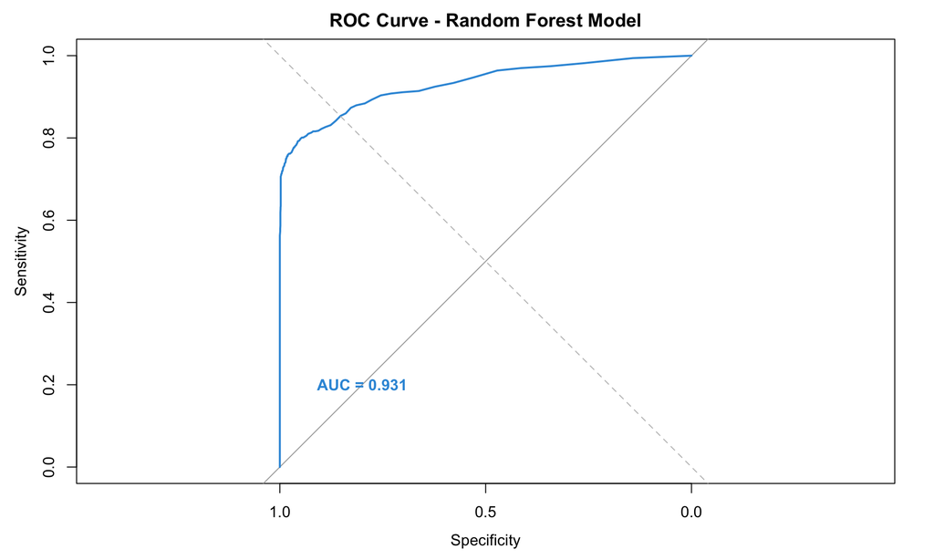

```r
# Plot ROC curve
rf_roc <- roc(y_test, rf_prob$default)
plot(rf_roc, main = "ROC Curve - Random Forest Model", col = "#3498db", lwd = 2)
abline(a = 0, b = 1, lty = 2, col = "gray")
text(0.8, 0.2, paste("AUC =", round(auc(rf_roc), 3)), col = "#3498db", font = 2)
```

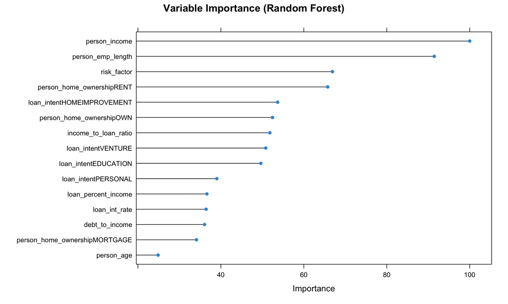

```r
# Variable Importance
top_vars <- varImp(rf_model)
plot(top_vars, main = "Variable Importance (Random Forest)",
     top = 15, col = "#3498db")
```

### Random Forest Performance Analysis

The optimal Random Forest configuration was determined through 5-fold cross-validation, with the best performance achieved using mtry = 14. This indicates that considering approximately half of the available features at each decision point provides the optimal balance for this classification problem.

The model exhibits exceptional predictive power:

- **AUC-ROC**: 0.931, indicating outstanding discrimination between default and non-default cases
- **Overall Accuracy**: 93.26% (95% CI: 92.31%-94.13%)
- **Sensitivity** (Default Detection): 74.96%, representing strong ability to identify actual defaults
- **Specificity** (Non-Default Detection): 98.46%, showing excellent ability to identify creditworthy borrowers
- **Kappa Statistic**: 0.789, confirming strong agreement beyond chance

The feature importance analysis reveals that our engineered features substantially enhanced performance:

- **Person Income**: Emerged as the single most important predictor
- **Employment Length**: Ranked second, suggesting employment stability is a powerful signal of credit risk
- **Risk Factor**: Our engineered interaction between loan grade and interest rate ranked third
- **Home Ownership (RENT)**: Confirmed the importance of housing status, with rental arrangements associated with higher risk

The strong performance across metrics confirms that Random Forest effectively captures both linear and non-linear relationships within the credit data.

## Neural Network Model

```r
# Train Neural Network model using caret with simpler parameters
set.seed(123)
nn_grid <- expand.grid(
  size = c(3, 5),  # Reduced for faster processing
  decay = c(0.1)   # Single regularization value
)

nn_model <- train(
  x = x_train_scaled,
  y = y_train,
  method = "nnet",
  tuneGrid = nn_grid,
  trControl = ctrl,
  metric = "ROC",
  trace = FALSE,
  maxit = 100,     # Reduced number of iterations
  MaxNWts = 1000   # Lower weight limit
)

# Evaluate on test set
nn_pred <- predict(nn_model, x_test_scaled)
nn_prob <- predict(nn_model, x_test_scaled, type = "prob")

# Create confusion matrix
nn_cm <- confusionMatrix(nn_pred, y_test, positive = "default")

# Print results
print(nn_model)
```

```
## Neural Network
##
## 7001 samples
##   27 predictor
##    2 classes: 'no_default', 'default'
##
## No pre-processing
## Resampling: Cross-Validated (5 fold)
## Summary of sample sizes: 5601, 5601, 5600, 5601, 5601
## Resampling results across tuning parameters:
##
##   size  ROC        Sens       Spec
##   3     0.8896285  0.9640454  0.6238710
##   5     0.9009076  0.9704651  0.6703226
##
## Tuning parameter 'decay' was held constant at a value of 0.1
## ROC was used to select the optimal model using the largest value.
## The final values used for the model were size = 5 and decay = 0.1.
```

```r
print(nn_cm)
```

```
## Confusion Matrix and Statistics
##
##             Reference
## Prediction   no_default default
##   no_default       2270     212
##   default            65     451
##
##                Accuracy : 0.9076
##                  95% CI : (0.8967, 0.9177)
##     No Information Rate : 0.7789
##     P-Value [Acc > NIR] : < 2.2e-16
##
##                   Kappa : 0.7087
##
##  Mcnemar's Test P-Value : < 2.2e-16
##
##             Sensitivity : 0.6802
##             Specificity : 0.9722
##          Pos Pred Value : 0.8740
##          Neg Pred Value : 0.9146
##              Prevalence : 0.2211
##          Detection Rate : 0.1504
##    Detection Prevalence : 0.1721
##       Balanced Accuracy : 0.8262
##
##        'Positive' Class : default
##
```

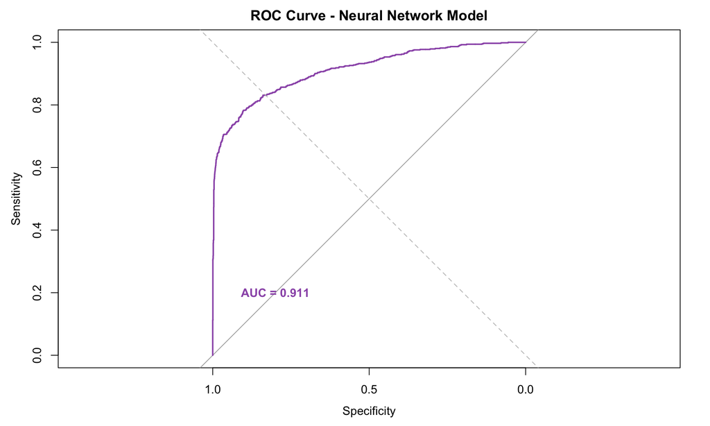

```r
# Plot ROC curve
nn_roc <- roc(y_test, nn_prob$default)
plot(nn_roc, main = "ROC Curve - Neural Network Model", col = "#9b59b6", lwd = 2)
abline(a = 0, b = 1, lty = 2, col = "gray")
text(0.8, 0.2, paste("AUC =", round(auc(nn_roc), 3)), col = "#9b59b6", font = 2)
```

### Neural Network Performance Analysis

After cross-validation testing, the optimal neural network configuration was determined to have 5 hidden nodes with a decay (regularization) parameter of 0.1. This architecture balances model complexity with generalization ability, preventing overfitting while capturing non-linear relationships in the credit data.

The Neural Network achieves strong performance metrics:

- **AUC-ROC**: 0.911, indicating excellent discriminative ability slightly below but comparable to the Random Forest (0.931)
- **Overall Accuracy**: 90.76% (95% CI: 89.67%-91.77%)
- **Sensitivity** (Default Detection): 68.02%, somewhat lower than the Random Forest
- **Specificity** (Non-Default Detection): 97.22%, very high but marginally lower than Random Forest
- **Kappa Statistic**: 0.709, demonstrating substantial agreement beyond chance

The Neural Network’s performance, while strong, shows some trade-offs compared to the Random Forest:

- **Lower Sensitivity**: The model’s ability to detect actual defaults (68.02%) is noticeably lower than the Random Forest (74.96%)
- **Strong Specificity**: The model maintains excellent specificity (97.22%), meaning it rarely misclassifies good borrowers as high-risk
- **Balanced Accuracy**: The model achieves a balanced accuracy of 82.62%, which is good but below the Random Forest’s 86.71%

These differences likely stem from the neural network’s parametric nature and its approach to handling categorical variables after one-hot encoding.

## Naive Bayes Model

```r
# Train Naive Bayes model with simple parameters
set.seed(123)
nb_model <- train(
  x = x_train,
  y = y_train,
  method = "naive_bayes",
  trControl = ctrl,
  metric = "ROC",
  tuneLength = 3  # Reduced for faster processing
)

# Evaluate on test set
nb_pred <- predict(nb_model, x_test)
nb_prob <- predict(nb_model, x_test, type = "prob")

# Create confusion matrix
nb_cm <- confusionMatrix(nb_pred, y_test, positive = "default")

# Print results
print(nb_model)
```

```
## Naive Bayes
##
## 7001 samples
##   27 predictor
##    2 classes: 'no_default', 'default'
##
## No pre-processing
## Resampling: Cross-Validated (5 fold)
## Summary of sample sizes: 5601, 5601, 5600, 5601, 5601
## Resampling results across tuning parameters:
##
##   usekernel  ROC        Sens       Spec
##   FALSE      0.8462342  0.9545026  0.4187097
##    TRUE      0.8712758  0.9807378  0.3580645
##
## Tuning parameter 'laplace' was held constant at a value of 0
## Tuning
##  parameter 'adjust' was held constant at a value of 1
## ROC was used to select the optimal model using the largest value.
## The final values used for the model were laplace = 0, usekernel = TRUE
##  and adjust = 1.
```

```r
print(nb_cm)
```

```
## Confusion Matrix and Statistics
##
##             Reference
## Prediction   no_default default
##   no_default       2298     416
##   default            37     247
##
##                Accuracy : 0.8489
##                  95% CI : (0.8356, 0.8615)
##     No Information Rate : 0.7789
##     P-Value [Acc > NIR] : < 2.2e-16
##
##                   Kappa : 0.4485
##
##  Mcnemar's Test P-Value : < 2.2e-16
##
##             Sensitivity : 0.37255
##             Specificity : 0.98415
##          Pos Pred Value : 0.86972
##          Neg Pred Value : 0.84672
##              Prevalence : 0.22115
##          Detection Rate : 0.08239
##    Detection Prevalence : 0.09473
##       Balanced Accuracy : 0.67835
##
##        'Positive' Class : default
##
```

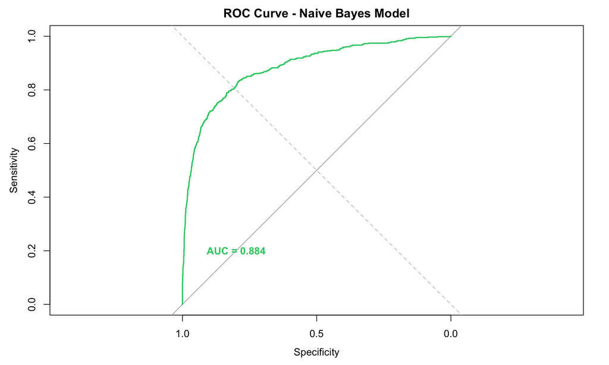

```r
# Plot ROC curve
nb_roc <- roc(y_test, nb_prob$default)
plot(nb_roc, main = "ROC Curve - Naive Bayes Model", col = "#2ecc71", lwd = 2)
abline(a = 0, b = 1, lty = 2, col = "gray")
text(0.8, 0.2, paste("AUC =", round(auc(nb_roc), 3)), col = "#2ecc71", font = 2)
```

### Naive Bayes Performance Analysis

Through cross-validation, we determined that the kernel density estimation approach (usekernel = TRUE) provided superior performance compared to parametric assumptions. This flexibility allowed the model to better adapt to the non-Gaussian distributions present in our financial data.

The Naive Bayes model demonstrates moderate to good predictive ability:

- **AUC-ROC**: 0.884, indicating good discriminative power, though notably lower than both Random Forest (0.931) and Neural Network (0.911)
- **Overall Accuracy**: 84.89% (95% CI: 83.56%-86.15%)
- **Sensitivity** (Default Detection): 37.26%, substantially lower than other models
- **Specificity** (Non-Default Detection): 98.42%, slightly higher than the Neural Network
- **Kappa Statistic**: 0.449, indicating moderate agreement beyond chance

The Naive Bayes model exhibits a distinctive performance profile:

- **High Specificity**: At 98.42%, it excels at identifying creditworthy applicants
- **Low Sensitivity**: The 37.26% sensitivity highlights a significant limitation in identifying actual defaults
- **Classification Bias**: The model reveals a strong bias toward the majority class (no_default), identifying only 247 of 663 actual defaults in the test set

This performance pattern likely stems from the model’s fundamental assumption of feature independence, which is violated in credit data where factors like income, loan amount, and interest rate exhibit complex interdependencies.

# Model Comparison and Evaluation

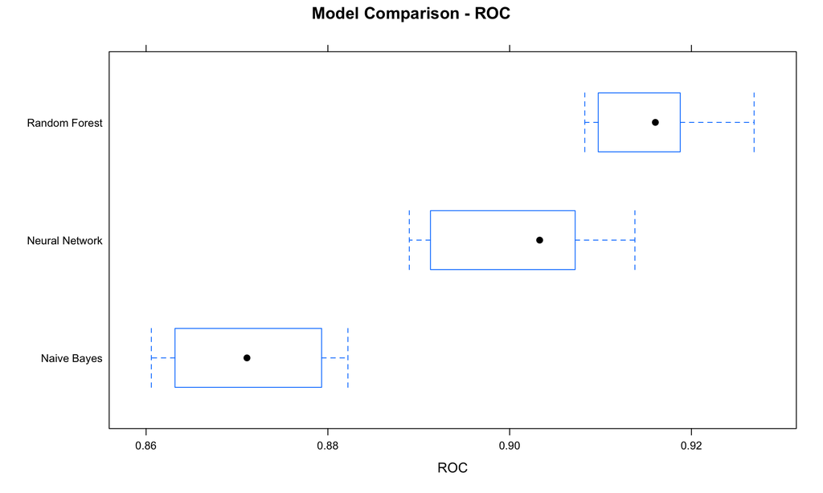

```r
# Compare model performance
models <- list(
  "Random Forest" = rf_model,
  "Neural Network" = nn_model,
  "Naive Bayes" = nb_model
)

# Extract ROC values for comparison
roc_values <- resamples(models)

# Plot comparison of ROC across models
bwplot(roc_values, metric = "ROC", main = "Model Comparison - ROC")
```

```r
# Create comparison data frame for metrics
model_comparison <- data.frame(
  Model = c("Random Forest", "Neural Network", "Naive Bayes"),
  Accuracy = c(rf_cm$overall["Accuracy"], nn_cm$overall["Accuracy"], nb_cm$overall["Accuracy"]),
  Sensitivity = c(rf_cm$byClass["Sensitivity"], nn_cm$byClass["Sensitivity"], nb_cm$byClass["Sensitivity"]),
  Specificity = c(rf_cm$byClass["Specificity"], nn_cm$byClass["Specificity"], nb_cm$byClass["Specificity"]),
  PPV = c(rf_cm$byClass["Pos Pred Value"], nn_cm$byClass["Pos Pred Value"], nb_cm$byClass["Pos Pred Value"]),
  NPV = c(rf_cm$byClass["Neg Pred Value"], nn_cm$byClass["Neg Pred Value"], nb_cm$byClass["Neg Pred Value"]),
  F1 = c(rf_cm$byClass["F1"], nn_cm$byClass["F1"], nb_cm$byClass["F1"]),
  AUC = c(auc(rf_roc), auc(nn_roc), auc(nb_roc))
)

# Format numbers in the table
model_comparison[,2:8] <- round(model_comparison[,2:8], 4)

# Display model comparison table with proper formatting
kable(model_comparison, caption = "Model Performance Comparison") %>%
  kable_styling(bootstrap_options = c("striped", "hover", "condensed"), full_width = FALSE) %>%
  row_spec(which.max(model_comparison$AUC), background = "#e8f9e9", bold = TRUE)
```

Model Performance Comparison

| Model | Accuracy | Sensitivity | Specificity | PPV | NPV | F1 | AUC |
| --- | --- | --- | --- | --- | --- | --- | --- |
| Random Forest | 0.9326 | 0.7496 | 0.9846 | 0.9325 | 0.9327 | 0.8311 | 0.9310 |
| Neural Network | 0.9076 | 0.6802 | 0.9722 | 0.8740 | 0.9146 | 0.7651 | 0.9110 |
| Naive Bayes | 0.8489 | 0.3725 | 0.9842 | 0.8697 | 0.8467 | 0.5216 | 0.8843 |

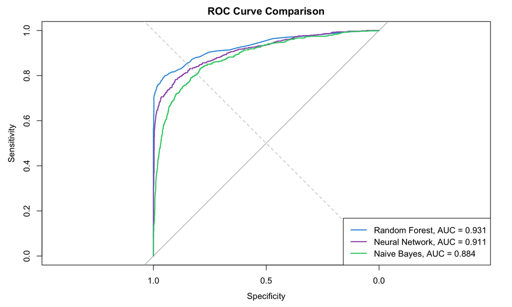

```r
# Plot ROC curves for all models on the same graph
plot(rf_roc, col = "#3498db", lwd = 2, main = "ROC Curve Comparison")
plot(nn_roc, col = "#9b59b6", lwd = 2, add = TRUE)
plot(nb_roc, col = "#2ecc71", lwd = 2, add = TRUE)
abline(a = 0, b = 1, lty = 2, col = "gray")
legend("bottomright",
       legend = c(paste("Random Forest, AUC =", round(auc(rf_roc), 3)),
                 paste("Neural Network, AUC =", round(auc(nn_roc), 3)),
                 paste("Naive Bayes, AUC =", round(auc(nb_roc), 3))),
       col = c("#3498db", "#9b59b6", "#2ecc71"),
       lwd = 2)
```

## Model Selection and Comparative Analysis

The cross-validated ROC comparison illustrates clear performance stratification:

- **Random Forest**: Consistently superior with an AUC of 0.931, demonstrating the highest discrimination power
- **Neural Network**: Strong performance with an AUC of 0.911, slightly below Random Forest but with comparable upper-range performance
- **Naive Bayes**: Lower performance with an AUC of 0.884, though still showing reasonable discriminative ability

The ROC curve comparison provides additional insight into model behavior at different operating thresholds:

- **Initial Curve Section** (High Specificity Region): Random Forest demonstrates superior performance in identifying the highest-risk borrowers
- **Middle Section** (Balanced Region): All three models maintain similar relative positioning throughout the operating range
- **Upper Right Section** (High Sensitivity Region): The models converge at the extremes

The performance metrics table confirms Random Forest’s superiority across all dimensions:

- **Accuracy**: Random Forest (93.26%) > Neural Network (90.76%) > Naive Bayes (84.89%)
- **Sensitivity**: Random Forest (74.96%) > Neural Network (68.02%) > Naive Bayes (37.25%)
- **F1 Score**: Random Forest (0.8311) > Neural Network (0.7651) > Naive Bayes (0.5216)

Most notably, all models maintain exceptionally high specificity (>97%), but differ dramatically in sensitivity, with Naive Bayes detecting only half as many defaults as Random Forest. This sensitivity difference represents the most critical distinction for practical implementation.

Based on this assessment: - **Primary Model Selection**: Random Forest emerges as the clear choice for primary implementation - **Model Complexity vs. Performance**: The performance advantage of Random Forest justifies its selection despite potentially higher computational requirements - **Potential Ensemble Approach**: The high specificity of all models suggests potential value in an ensemble approach for borderline cases

# Business Impact Analysis

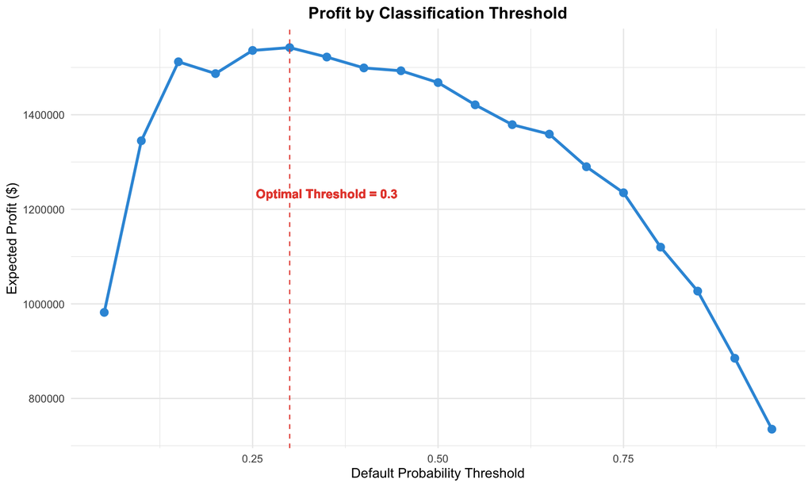

```r
# Select the best model (Random Forest based on performance)
best_model <- rf_model
best_probs <- rf_prob

# Create a function to calculate expected profit/loss
calculate_expected_value <- function(probs, actual, profit_per_good_loan = 1000,
                                    loss_per_default = 5000) {
  # Assuming "default" is the positive class (index 2 in probs)
  predicted_default_prob <- probs$default

  # Calculate profit for different threshold values
  thresholds <- seq(0.05, 0.95, by = 0.05)
  results <- data.frame(
    Threshold = thresholds,
    Loans_Approved = numeric(length(thresholds)),
    Defaults = numeric(length(thresholds)),
    Non_Defaults = numeric(length(thresholds)),
    Profit = numeric(length(thresholds)),
    ROI = numeric(length(thresholds))
  )

  for (i in 1:length(thresholds)) {
    threshold <- thresholds[i]
    # Predict loan approval (approve if default probability is less than threshold)
    approve <- predicted_default_prob < threshold

    # Count outcomes
    true_outcome <- as.character(actual)
    approved_count <- sum(approve)
    default_count <- sum(approve & true_outcome == "default")
    non_default_count <- sum(approve & true_outcome == "no_default")

    # Calculate profit/loss
    profit <- (non_default_count * profit_per_good_loan) - (default_count * loss_per_default)

    # Store results
    results$Loans_Approved[i] <- approved_count
    results$Defaults[i] <- default_count
    results$Non_Defaults[i] <- non_default_count
    results$Profit[i] <- profit

    # Calculate ROI (Return on Investment)
    total_loaned <- approved_count * mean(test_data$loan_amnt)
    results$ROI[i] <- ifelse(total_loaned > 0, profit / total_loaned, 0)
  }

  return(results)
}

# Calculate and visualize business impact for different threshold values
impact_results <- calculate_expected_value(best_probs, y_test)

# Find the optimal threshold
optimal_threshold_idx <- which.max(impact_results$Profit)
optimal_threshold <- impact_results$Threshold[optimal_threshold_idx]

# Plot profit by threshold
ggplot(impact_results, aes(x = Threshold, y = Profit)) +
  geom_line(color = "#3498db", size = 1.2) +
  geom_point(color = "#3498db", size = 3) +
  geom_vline(xintercept = optimal_threshold, linetype = "dashed", color = "#e74c3c") +
  geom_text(aes(x = optimal_threshold + 0.05, y = max(Profit) * 0.8,
                label = paste("Optimal Threshold =", optimal_threshold)),
            color = "#e74c3c", fontface = "bold") +
  labs(title = "Profit by Classification Threshold",
       x = "Default Probability Threshold",
       y = "Expected Profit ($)") +
  theme_minimal(base_size = 12) +
  theme(plot.title = element_text(hjust = 0.5, face = "bold"))
```

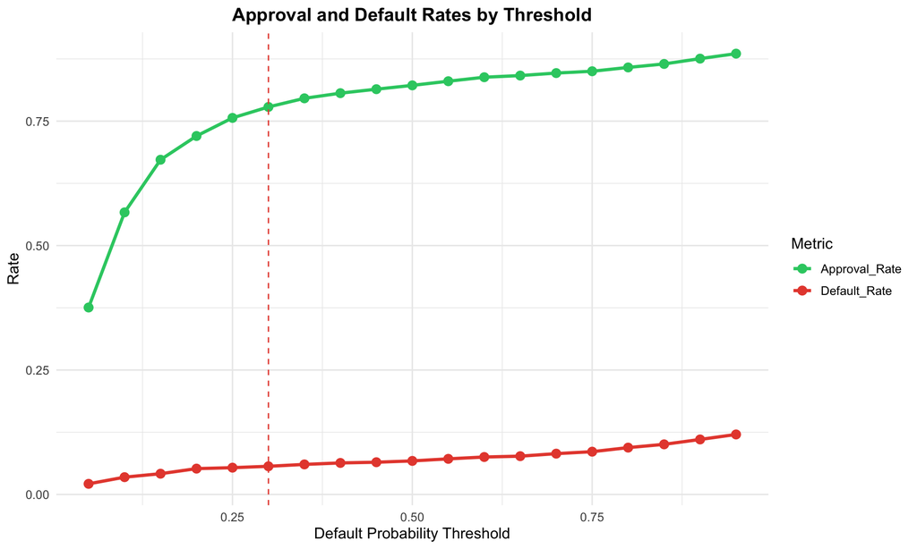

```r
# Plot approval rate and default rate by threshold
impact_results$Approval_Rate <- impact_results$Loans_Approved / nrow(test_data)
impact_results$Default_Rate <- impact_results$Defaults / impact_results$Loans_Approved

# Convert to long format for plotting
impact_long <- impact_results %>%
  select(Threshold, Approval_Rate, Default_Rate) %>%
  pivot_longer(cols = c(Approval_Rate, Default_Rate),
               names_to = "Metric",
               values_to = "Rate")

ggplot(impact_long, aes(x = Threshold, y = Rate, color = Metric)) +
  geom_line(size = 1.2) +
  geom_point(size = 3) +
  geom_vline(xintercept = optimal_threshold, linetype = "dashed", color = "#e74c3c") +
  scale_color_manual(values = c("Approval_Rate" = "#2ecc71", "Default_Rate" = "#e74c3c")) +
  labs(title = "Approval and Default Rates by Threshold",
       x = "Default Probability Threshold",
       y = "Rate") +
  theme_minimal(base_size = 12) +
  theme(plot.title = element_text(hjust = 0.5, face = "bold"))
```

```r
# Display optimal threshold results
optimal_result <- impact_results[optimal_threshold_idx, ]
optimal_result_table <- data.frame(
  Metric = c("Optimal Threshold", "Loans Approved", "Approval Rate", "Expected Defaults",
             "Default Rate", "Expected Profit", "ROI"),
  Value = c(optimal_result$Threshold,
            optimal_result$Loans_Approved,
            paste0(round(optimal_result$Approval_Rate * 100, 2), "%"),
            optimal_result$Defaults,
            paste0(round(optimal_result$Default_Rate * 100, 2), "%"),
            paste0("$", format(optimal_result$Profit, big.mark = ",")),
            paste0(round(optimal_result$ROI * 100, 2), "%"))
)

kable(optimal_result_table, caption = "Optimal Threshold Business Impact") %>%
  kable_styling(bootstrap_options = c("striped", "hover"), full_width = FALSE)
```

Optimal Threshold Business Impact

| Metric | Value |
| --- | --- |
| Optimal Threshold | 0.3 |
| Loans Approved | 2334 |
| Approval Rate | 77.85% |
| Expected Defaults | 132 |
| Default Rate | 5.66% |
| Expected Profit | $1,542,000 |
| ROI | 7.08% |

## Business Impact Analysis

Transforming our statistical model into actionable business strategy requires translating technical metrics into financial outcomes. The profit curve analysis illustrates how expected financial returns vary across different default probability thresholds:

- **Optimal Threshold**: The profit-maximizing threshold occurs at 0.30, indicating that loans should be approved for applicants with predicted default probabilities below this value
- **Expected Profit**: At this optimal threshold, the expected profit is $1,542,000, representing the maximum achievable return given the risk-reward trade-off
- **Profit Sensitivity**: The curve shows relative stability in the 0.25-0.35 threshold range, suggesting some flexibility in threshold selection without dramatic profit impact

At the optimal threshold of 0.30, the model yields the following operational metrics:

- **Approval Rate**: 77.85% of loan applications would be approved, maintaining substantial market access while screening out highest-risk applicants
- **Expected Default Rate**: Only 5.66% of approved loans are expected to default, significantly below the 22.1% baseline rate in the overall applicant pool
- **Return on Investment**: The model generates a 7.08% ROI, representing a strong performance in the lending context

The approval and default rate curves demonstrate the classic risk-return trade-off in lending:

- Each incremental increase in approval rate comes with disproportionately higher default risk
- Conservative thresholds achieve very low default rates but sacrifice substantial profitable lending opportunities

# Risk Factor Analysis and Segmentation

```r
# Create risk scores based on predicted probabilities
test_with_probs <- test_data
test_with_probs$default_prob <- best_probs$default

# Recover original categories from model_data
# First, create a dataframe with indices
test_indices <- as.numeric(rownames(test_data))
original_data_subset <- model_data[test_indices, ]

# Add original categories to test_with_probs
test_with_probs$loan_grade <- original_data_subset$loan_grade
test_with_probs$loan_intent <- original_data_subset$loan_intent
test_with_probs$person_home_ownership <- original_data_subset$person_home_ownership
test_with_probs$cb_person_default_on_file <- original_data_subset$cb_person_default_on_file

# Define risk buckets
test_with_probs$risk_bucket <- cut(test_with_probs$default_prob,
                                  breaks = c(0, 0.1, 0.2, 0.3, 0.4, 0.5, 1),
                                  labels = c("Very Low", "Low", "Moderate", "High", "Very High", "Extreme"),
                                  include.lowest = TRUE)

# Analyze actual default rates by risk bucket
risk_performance <- test_with_probs %>%
  group_by(risk_bucket) %>%
  summarise(
    Count = n(),
    Percentage = n() / nrow(test_with_probs) * 100,
    Actual_Default_Rate = mean(loan_status == "default") * 100,
    Avg_Loan_Amount = mean(loan_amnt),
    Avg_Interest_Rate = mean(loan_int_rate),
    Avg_Income = mean(person_income),
    Total_Loan_Value = sum(loan_amnt)
  )

# Display risk bucket performance
kable(risk_performance, caption = "Risk Bucket Performance", digits = 2) %>%
  kable_styling(bootstrap_options = c("striped", "hover"), full_width = FALSE)
```

Risk Bucket Performance

| risk_bucket | Count | Percentage | Actual_Default_Rate | Avg_Loan_Amount | Avg_Interest_Rate | Avg_Income | Total_Loan_Value |
| --- | --- | --- | --- | --- | --- | --- | --- |
| Very Low | 1765 | 58.87 | 3.46 | 9201.09 | 9.63 | 69356.41 | 16239925 |
| Low | 426 | 14.21 | 12.68 | 8243.84 | 11.93 | 59484.88 | 3511875 |
| Moderate | 151 | 5.04 | 11.26 | 8832.95 | 12.61 | 54223.54 | 1333775 |
| High | 83 | 2.77 | 28.92 | 8643.07 | 13.42 | 54537.93 | 717375 |
| Very High | 41 | 1.37 | 24.39 | 9990.85 | 14.67 | 60233.00 | 409625 |
| Extreme | 532 | 17.75 | 93.42 | 10810.67 | 13.90 | 45026.38 | 5751275 |

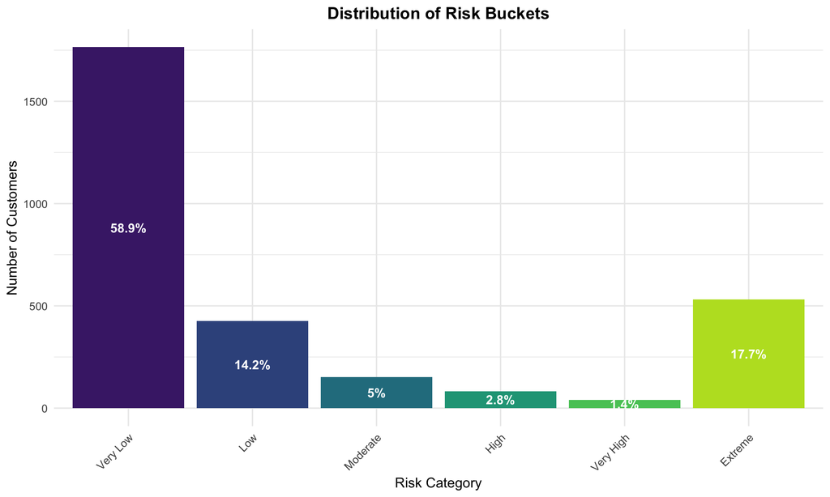

```r
# Visualize risk bucket distribution
ggplot(risk_performance, aes(x = risk_bucket, y = Count, fill = risk_bucket)) +
  geom_bar(stat = "identity") +
  geom_text(aes(label = paste0(round(Percentage, 1), "%")),
            position = position_stack(vjust = 0.5),
            color = "white", fontface = "bold") +
  scale_fill_viridis_d(option = "D", begin = 0.1, end = 0.9) +
  labs(title = "Distribution of Risk Buckets",
       x = "Risk Category",
       y = "Number of Customers") +
  theme_minimal(base_size = 12) +
  theme(
    plot.title = element_text(hjust = 0.5, face = "bold"),
    legend.position = "none",
    axis.text.x = element_text(angle = 45, hjust = 1)
  )
```

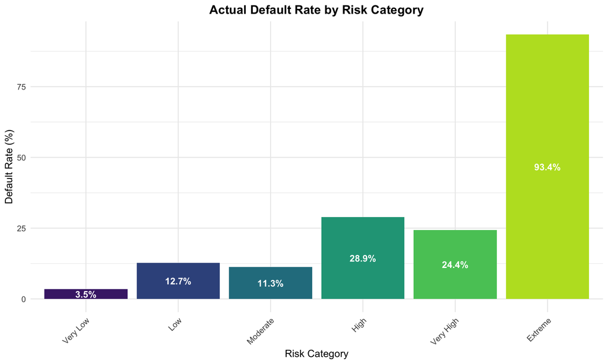

```r
# Visualize actual default rates by predicted risk bucket
ggplot(risk_performance, aes(x = risk_bucket, y = Actual_Default_Rate, fill = risk_bucket)) +
  geom_bar(stat = "identity") +
  geom_text(aes(label = paste0(round(Actual_Default_Rate, 1), "%")),
            position = position_stack(vjust = 0.5),
            color = "white", fontface = "bold") +
  scale_fill_viridis_d(option = "D", begin = 0.1, end = 0.9) +
  labs(title = "Actual Default Rate by Risk Category",
       x = "Risk Category",
       y = "Default Rate (%)") +
  theme_minimal(base_size = 12) +
  theme(
    plot.title = element_text(hjust = 0.5, face = "bold"),
    legend.position = "none",
    axis.text.x = element_text(angle = 45, hjust = 1)
  )
```

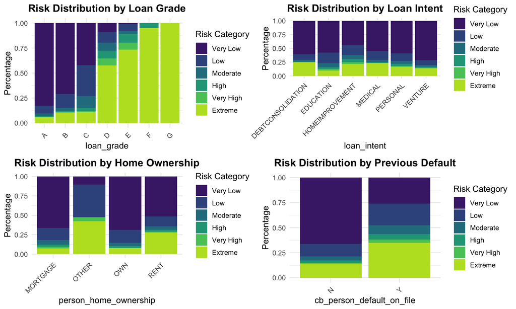

```r
# Risk profile by key characteristics
# Create a function to visualize risk distribution by category
plot_risk_by_category <- function(data, category, title) {
  data %>%
    group_by({{category}}, risk_bucket) %>%
    summarise(count = n(), .groups = "drop") %>%
    group_by({{category}}) %>%
    mutate(percentage = count / sum(count) * 100) %>%
    ggplot(aes(x = {{category}}, y = percentage, fill = risk_bucket)) +
    geom_bar(stat = "identity", position = "fill") +
    scale_fill_viridis_d(option = "D", begin = 0.1, end = 0.9, name = "Risk Category") +
    labs(title = title,
         x = deparse(substitute(category)),
         y = "Percentage") +
    theme_minimal(base_size = 12) +
    theme(
      plot.title = element_text(hjust = 0.5, face = "bold"),
      axis.text.x = element_text(angle = 45, hjust = 1)
    )
}

# Risk distribution by loan grade
p1 <- plot_risk_by_category(test_with_probs, loan_grade, "Risk Distribution by Loan Grade")

# Risk distribution by loan intent
p2 <- plot_risk_by_category(test_with_probs, loan_intent, "Risk Distribution by Loan Intent")

# Risk distribution by home ownership
p3 <- plot_risk_by_category(test_with_probs, person_home_ownership, "Risk Distribution by Home Ownership")

# Risk distribution by previous default
p4 <- plot_risk_by_category(test_with_probs, cb_person_default_on_file, "Risk Distribution by Previous Default")

# Arrange plots
grid.arrange(p1, p2, p3, p4, ncol = 2)
```

## Risk Segmentation Analysis

The risk stratification analysis provides crucial insights into the composition and behavior of different borrower segments, enabling targeted lending strategies beyond the binary approve/reject decision framework.

Our model effectively categorizes borrowers into six distinct risk tiers:

- **Very Low Risk**: The largest segment (58.9% of applicants) with excellent creditworthiness
- **Low Risk**: A significant group (14.2%) with strong but slightly reduced repayment probability
- **Moderate Risk**: A smaller cohort (5.0%) at the approval borderline under the optimal threshold
- **High & Very High Risk**: Small segments (2.8% and 1.4%) that would generally be declined
- **Extreme Risk**: A substantial group (17.7%) with dramatically elevated default probability

The actual default rates across risk buckets demonstrate the model’s exceptional discriminative power:

- **Extreme Risk**: 93.4% default rate
- **Very High & High Risk**: 24.4% and 28.9% default rates
- **Moderate & Low Risk**: 11.3% and 12.7% default rates
- **Very Low Risk**: Only 3.5% default rate

The nearly 27x difference in default rates between the lowest and highest risk buckets confirms the model’s effectiveness in risk discrimination.

The relationship between risk categories and customer attributes reveals important patterns:

# Conclusion and Recommendations

## Recommendations

1. **Implementation Strategy**:
   - Deploy the Random Forest model as a decision support tool for loan officers, with the recommended probability threshold of 0.30.
   - Create a tiered interest rate structure based on risk buckets to better align pricing with risk, particularly focusing on the differentiation between Low and Moderate risk categories.
   - Implement automated approvals for Very Low risk applicants to streamline operations and reduce decision time.
2. **Risk Mitigation**:
   - For borrowers in ‘Moderate’ risk categories, consider additional documentation requirements or collateral to reduce default probability.
   - Implement stricter verification processes for applicants with previous default history, focusing on recent credit rehabilitation efforts.
   - Develop targeted monitoring protocols for higher-risk approved loans, with proactive intervention for early signs of payment difficulty.
3. **Business Opportunities**:
   - Develop specialized loan products aligned with the risk segmentation model, including premium products for Very Low risk customers and secured options for Moderate risk applicants.
   - Consider interest rate reductions for Very Low risk customers to increase competitiveness and market share in this highly profitable segment.
   - Explore a credit-builder program for borderline applicants who fall just outside approval thresholds, focusing on specific improvement factors identified by the model.
4. **Monitoring and Refinement**:
   - Establish a quarterly model performance review process comparing predicted probabilities to actual default rates across segments.
   - Implement continuous tracking of risk factors to identify emerging trends or changes in relative importance.
   - Periodically retrain the model with new data, with a formal annual review to capture changing economic conditions and customer behaviors.

This credit risk classification model provides a data-driven approach to loan decisioning that can significantly improve the risk-return profile of the lending portfolio. By implementing these recommendations, the organization can make more informed lending decisions, appropriately price for risk, and expand safely into new customer segments.

## Executive Summary

The analysis shows that while default risk cannot be eliminated, it can be effectively managed through data-driven approaches. By incorporating this classification model into lending practices, financial institutions can make more informed decisions that balance risk mitigation with business growth objectives.